# MRFcov trials

# Trials for MRF package with supplied data to decipher the syntax and data structure required!

Data has to have the following structure:

- rownames = sites
- colnames = species

## `MRFcov()` Markov Random Fields with covariates

This function is the workhorse of the MRFcov package, running separate penalized regressions for each node to estimate parameters of Markov Random Fields (MRF) graphs. Covariates can be included (a class of models known as Conditional Random Fields; CRF), to estimate how interactions between nodes vary across covariate magnitudes.

```r
sym_mean <- MRFcov(data = Bird.parasites, n_nodes = 4, family = "binomial") # symmetrise = mean
```

```
Leave-one-out cv used for the following low-occurrence (rare) nodes:
 Microfilaria ...
Fitting MRF models in sequence using 1 core ...

  |                                                  | 0 % ~calculating
  |+++++++++++++                                     | 25% ~01s
  |+++++++++++++++++++++++++                         | 50% ~00s
  |++++++++++++++++++++++++++++++++++++++            | 75% ~00s
  |++++++++++++++++++++++++++++++++++++++++++++++++++| 100% elapsed=01s
```

`symmetrise`: The method to use for symmetrising corresponding parameter estimates (which are taken from separate regressions). Options are min (take the coefficient with the smallest absolute value), max (take the coefficient with the largest absolute value) or mean (take the mean of the two coefficients). Default is mean.

## `plotMRF_hm` Plot MRF interaction parameters as a heatmap

This function uses outputs from fitted MRFcov and bootstrap_MRF models to plot a heatmap of node interaction coefficients.

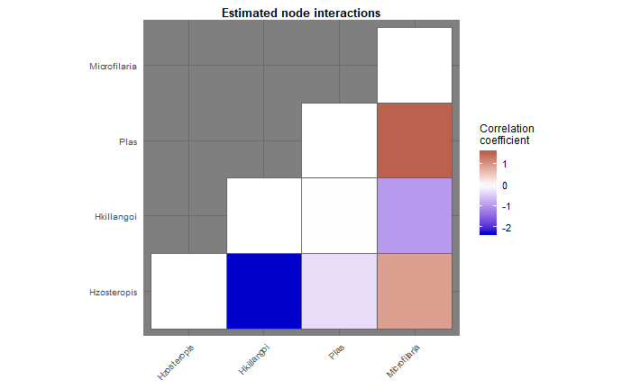

from the vignette: > These represent predicted interactions when the covariate is set to its mean (i.e. in this case, when scale.prop.zos = 0). If we had included other covariates, then this graph would represent interactions predicted when all covariates were set at their means

> Regression coefficients and their relative importances can be accessed as well. This call returns a matrix of the raw coefficient, as well as standardised coefficients (standardised by the sd of the covariate). Standardisation in this way helps to compare the relative influences of each parameter on the target species’ occurrence probability, but in general the two coefficients will be identical (unless users have not pre-scaled their covariates). The list also contains contains each variable’s relative importance (calculated using the formula B^2 / sum(B^2), where the vector of Bs represents regression coefficients for predictor variables). Variables with an underscore (*) indicate an interaction between a covariate and another node, suggesting that conditional dependencies of the two nodes vary across environmental gradients. Because of this, it is recommended to avoid using column names with* in them

|  | Variable | Rel_importance | Standardised_coef | Raw_coef |
| --- | --- | --- | --- | --- |
| 1 | Hkillangoi | 0.65772844 | -2.2676686 | -2.2676686 |
| 5 | scale.prop.zos_Microfilaria | 0.12544520 | -0.9903377 | -0.9903377 |
| 3 | Microfilaria | 0.10814835 | 0.9195307 | 0.9195307 |
| 4 | scale.prop.zos | 0.09308106 | -0.8530744 | -0.8530744 |
| 2 | Plas | 0.01272760 | -0.3154493 | -0.3154493 |

`scale.prop.zos_Microfilaria` = conditional dependency between them.

> Finally, a useful capability is to generate some fake data and test predictions. For instance, say we want to know how frequently malaria parasite infections are predicted to occur in sites with high occurrence of microfilaria.

```r
H.zos.pred.prev
```

```
[1] 0.3140312
```

> We can explore regression coefficients to get a better understanding of just how important interactions are for predicting species’ occurrence probabilities (in comparison to other covariates).

First we need to bootstrap the data, then check the coefficients:

|  | Variable | Rel_importance | Mean_coef |
| --- | --- | --- | --- |
| 2 | Microfilaria | 0.65048595 | 1.5097661 |
| 3 | scale.prop.zos | 0.26481741 | -0.9633054 |
| 4 | scale.prop.zos_Microfilaria | 0.04796581 | 0.4099743 |
| 1 | Hzosteropis | 0.02941369 | -0.3210447 |

## `prep_MRF_covariates` Cross-multiply response and covariate variables

This function performs the cross-multiplication necessary for prepping datasets to be used in MRFcov models. This function is called by several of the functions within the package.

Now I have the co-occurence probabilities (I’ll use the one based on mean symmetrise value), I’d like to add a covariate (relative abundance of host species):

```r
birds_cov <- prep_MRF_covariates(data = Bird.parasites, n_nodes = 4) # I use the full dataframe where the left-most columns are species and then afer them: covariates

# now add this to MRFcov:
mrf_birds_cov <- MRFcov(data = Bird.parasites, n_nodes = 4, prep_covariates = TRUE, family = "binomial")
plotMRF_hm(mrf_birds_cov)
```

[output not shown]

Incorporating a covariate yields the same looking grpah but I’m not sure which abundance this graph is relevant for..

## `predict_MRF` Predict training observations from fitted MRFcov models

This function calculates linear predictors for node observations using coefficients from an MRFcov or MRFcov_spatial object.

```r
apply(bird_predictors, 2, summary)
```

```
Error in apply(bird_predictors, 2, summary) :
  dim(X) must have a positive length
```

# `predict_MRFnetworks` Extract predicted network metrics for observations in a given dataset using equations from a fitted MRFcov object

This function uses outputs from fitted MRFcov and bootstrap_MRF models to generate linear predictions for each observation in data and calculate probabilistic network metrics from weighted adjacency matrices.

`bootstrap_MRF` Bootstrap observations to estimate MRF parameter coefficients This function runs MRFcov models multiple times to capture uncertainty in parameter esimates. The dataset is shuffled and missing values (if found) are imputed in each bootstrap iteration.

work with igraph package to create a graphical representation of the data:

```r
network <- graph.adjacency(mrf_birds_cov$graph, weighted = T, mode = "undirected") # inside the MRFcov new variable there is a graph element which I'll need to use for igraph
plot.igraph(network, layout = layout.circle(network),
            edge.width = abs(E(network)$weight),
            edge.color = ifelse(E(network)$weight < 0,
                                          'blue',
                                          'red'))
```

[output not shown]